# MPA 5830 - Task 05 Solutions

Ani Ruhil

2018-08-03

# (1)

Create a map of the 48 states in the continental United States with `ggplot2`. Make sure the state names are displayed in title-case on the map, along with the state borders. Title the map with an appropriate title. Make sure the legend is not visible.

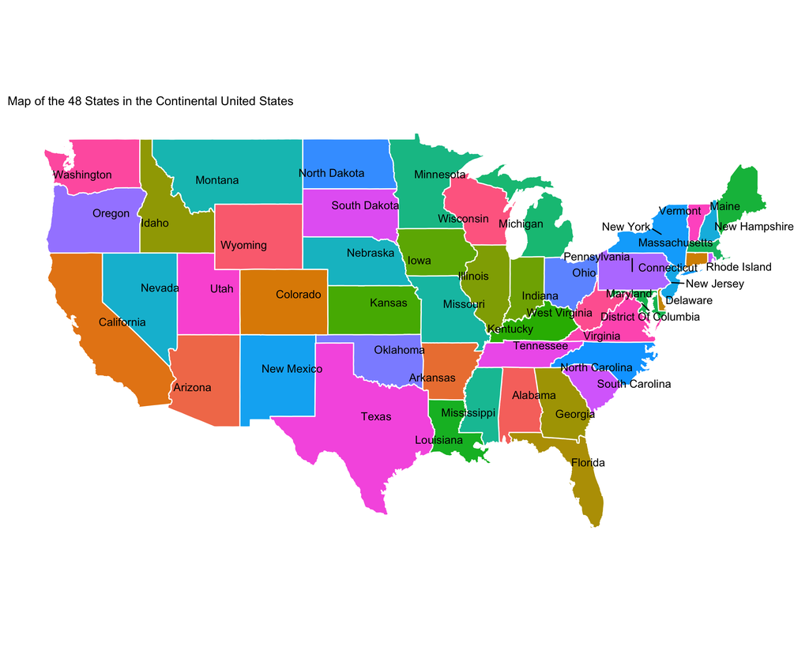

```r
library(ggplot2)
library(ggmap)
library(maps)
library(maptools)
library(ggthemes)
library(ggrepel)

state.df <- map_data("state")

library(stringr)
state.df$state = str_to_title(state.df$region)

library(sp)
getLabelPoint <- function(state) {
    Polygon(state[c("long", "lat")])@labpt
}
centroids = by(state.df, state.df$state,
    getLabelPoint)  # Returns list
centroids2 <- do.call("rbind.data.frame",
    centroids)  # Convert to Data Frame
centroids2$statename = rownames(centroids)
names(centroids2) <- c("clong", "clat", "statename")

ggplot(state.df, aes(x = long, y = lat, group = group)) +
    geom_polygon(aes(fill = region), color = "white") +
    coord_fixed(1.3) + geom_text_repel(data = centroids2,
    aes(x = clong, y = clat, group = statename,
        label = statename), size = 3.5) +
    theme_map() + theme(legend.position = "none") +
    labs(title = "Map of the 48 States in the Continental United States")
```

# (2)

Now create a data-frame of California’s counties. Use [this link to download CA counties’ 2018 Health Ranking data](http://www.countyhealthrankings.org/sites/default/files/state/downloads/2018%20County%20Health%20Rankings%20California%20Data%20-%20v1.xls). The measure you want is the `% Obese` so read-in this measure (along with county names) as a data-frame. Now you need to create a map of CA counties, with the county names displayed, and the map filled-in with the quartiles of obesity (`Hint:` You want the FOUR groups to be labeled “0-25”, “25-50”, “50-75”, “75-100”). Title the map and make sure the legend is visible, along with a caption that provides the source of the obesity measure. Place the legend at the bottom of the map.

Now, does it look like counties in CA have a spatial pattern to obesity (i.e., are the counties in the 75-100 group – the ones with the highest obesity levels – clustered together or does the map exhibit no pattern)?

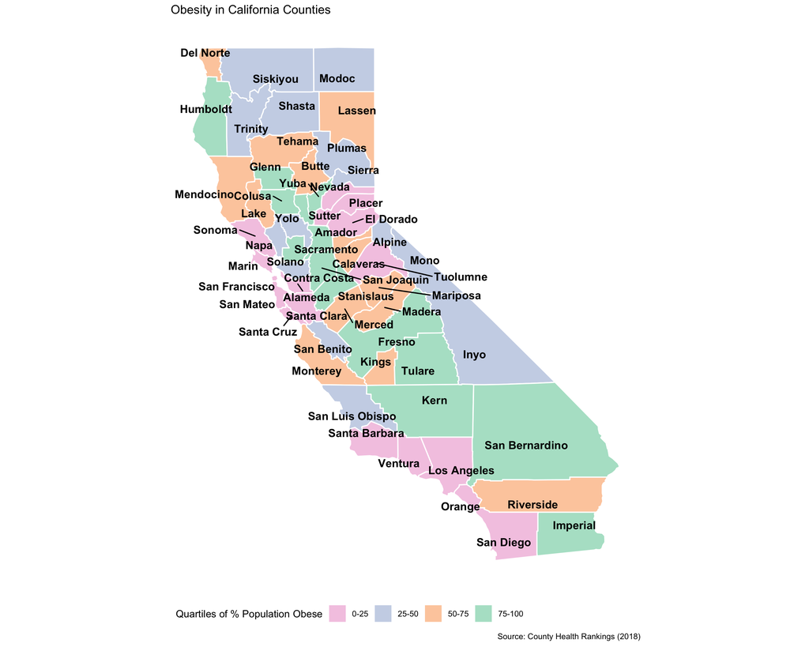

```r
cacounties <- map_data("county", region = "CA")

cacounties$county = str_to_title(cacounties$subregion)

getLabelPoint <- function(county) {
    Polygon(county[c("long", "lat")])@labpt
}
centroids = by(cacounties, cacounties$county,
    getLabelPoint)  # Returns list
centroids2 <- do.call("rbind.data.frame",
    centroids)  # Convert to Data Frame
centroids2$countyname = rownames(centroids)
names(centroids2) <- c("clong", "clat", "countyname")

library(readxl)
obesity <- read_excel("~/Documents/Teaching/mpa5830/data/cacountiesCHR.xlsx")

my.df = merge(cacounties, obesity, by = "county",
    all.x = TRUE, sort = FALSE)

my.df = my.df[order(my.df$order), ]

library(dplyr)
my.df2 <- my.df %>% mutate(grouped_obesity = cut(obesity,
    breaks = c(quantile(my.df$obesity, probs = seq(0,
        1, by = 0.25))), labels = c("0-25",
        "25-50", "50-75", "75-100"), include.lowest = TRUE))

ggplot(my.df2, aes(x = long, y = lat, group = group)) +
    geom_polygon(aes(fill = grouped_obesity),
        color = "white") + coord_fixed(1.3) +
    geom_text_repel(data = centroids2, aes(x = clong,
        y = clat, group = countyname, label = countyname),
        size = 3.5, color = "black", fontface = "bold") +
    scale_fill_brewer(palette = "Pastel2",
        direction = -1) + theme_map() + theme(legend.position = "bottom") +
    labs(title = "Obesity in California Counties",
        fill = "Quartiles of % Population Obese",
        caption = "Source: County Health Rankings (2018)")
```

The map does show a spatial pattern, with many of the counties in a particular obesity quartile tending to be adjacent to one another. The only ones that are not, for the highest obesity levels, are Imperial and Humboldt.

# (3)

Use Google maps to find the latitude/longitude of THREE hospitals closest to your current place of residence. Note the name of each hospital as well. Now use `leaflet` to generate a map that shows each of these three hospitals as popups. Display the hospitals’ names.

```r
library(leaflet)
library(leaflet.extras)
library(widgetframe)

hospitals <- data.frame(names = c("Ohio Health O'Bleness Hospital",
    "Ohio University Student Health Center",
    "Athens Medical Associates"), nlat = c(39.334411,
    39.331622, 39.35153), nlng = c(-82.123221,
    -82.097986, -82.095325))

pl1 <- leaflet() %>% setView(lat = 39.332577,
    lng = -82.106336, zoom = 13) %>% addMarkers(lat = hospitals$nlat,
    lng = hospitals$nlng, popup = hospitals$names) %>%
    addProviderTiles(providers$Esri.NatGeoWorldMap) %>%
    setMapWidgetStyle() %>% frameWidget(height = "475")
pl1
```

[interactive chart not shown]

# (4)

Using the `epa` data-set create four graphics – a bar-chart, a scatter-plot, a histogram, and a box-plot. Display all four graphics on a single canvas via `patchwork`. Make sure you label the graphs’ components (at minimum, the axis-labels and a title).

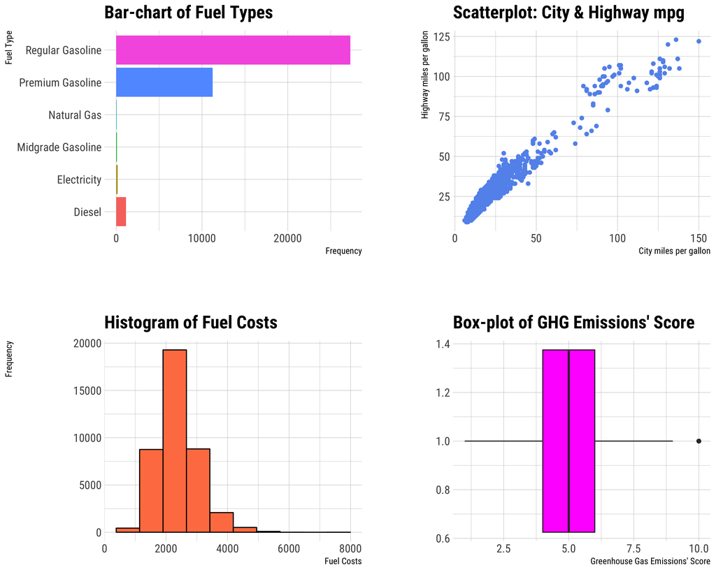

```r
library(ggplot2)
library(hrbrthemes)
library(patchwork)

load("~/Documents/Teaching/mpa5830/data/epa.RData")

p1 <- ggplot(epa, aes(x = fuelType1, fill = fuelType1)) +
    geom_bar() + labs(x = "Fuel Type", y = "Frequency",
    title = "Bar-chart of Fuel Types") +
    coord_flip() + theme_ipsum_rc() + theme(title = element_text(size = 7),
    legend.position = "none")
p2 <- ggplot(epa, aes(x = city08, y = highway08)) +
    geom_point(color = "cornflowerblue") +
    labs(x = "City miles per gallon", y = "Highway miles per gallon",
        title = "Scatterplot: City & Highway mpg") +
    theme(title = element_text(size = 7)) +
    theme_ipsum_rc()
p3 <- ggplot(epa, aes(x = fuelCost08)) +
    geom_histogram(bins = 10, fill = "coral",
        color = "black") + labs(x = "Fuel Costs",
    y = "Frequency", title = "Histogram of Fuel Costs") +
    theme_ipsum_rc() + theme(title = element_text(size = 7))
p4 <- ggplot(subset(epa, ghgScore > 0), aes(x = 1,
    y = ghgScore)) + geom_boxplot(fill = "magenta") +
    coord_flip() + labs(y = "Greenhouse Gas Emissions' Score",
    x = "", title = "Box-plot of GHG Emissions' Score") +
    theme(title = element_text(size = 7)) +
    theme_ipsum_rc()

p1 + p2 + p3 + p4 + plot_layout(ncol = 2)
```